# Analyzing Data from the CIA World Factbook

By: Kaman Phamdo

### **Introduction**

The [CIA World Factbook](https://www.cia.gov/library/publications/the-world-factbook/) contains data about people, government, economy, communications, and more for each world entity. In this tutorial, you will learn how to curate data from The CIA World Factbook and perform analysis to answer interesting questions about countries around the world. In particular, we will be collecting data about expected years spent in school, education expenditures, literacy, and unemployment rate in each country. Then, we will use data science techniques such as exploratory analysis, visualization, linear regression, and machine learning to analyze the relationship between education and unemployment rate.

### **Background**

Studies show that limitations in education can lead to higher unemployment rates, and that the development of education can increase employment in certain countries. Here are some background readings that investigate the relationship between education and unemployment:

- [The relationship between education and employment: A theoretical analysis and empirical test](https://link.springer.com/article/10.1007/s11459-007-0010-4)
- [Where Unemployment Is Highest, Education Is A Big Part Of Why](https://www.forbes.com/sites/susanadams/2012/08/29/where-unemployment-is-highest-education-is-a-big-part-of-why/#3c1085cf29c5)
- [Unemployment rates and earnings by educational attainment](https://www.bls.gov/emp/ep_chart_001.htm)

These studies suggest that there is a positive correlation between education and employment within a specific country such as the United States. In this project, we take our analyses to a broader scale to investigate all countries on an international level. This information could indicate whether differences in education expenditures or educational structure in a country can lead to a change in unemployment rates.

### **Required Tools**

We will be using R: https://www.r-project.org/.  
You will also need to install and import the following packages:

```r
library(rvest)
library(stringr)
library(ggplot2)
library(dplyr)
library(broom)
library(plyr)
```

### **Data Curation**

The [CIA World Factbook](https://www.cia.gov/library/publications/the-world-factbook/) contains information about each country in a separate webpage. This data is pretty messy, so it will take a bit of work to parse all of the HTML into a more readable data frame in R.  
First, we will obtain a list of all the countries and their corresponding webpages. On the front page of the factbook, you will find a drop-down menu containing this information. Using the rvest package, we can parse the HTML for “option” nodes in this menu. This will give us a list of all the countries and their corresponding webpage.

```r
webpage <- read_html("https://www.cia.gov/library/publications/the-world-factbook/")
countries <- webpage %>%
  html_nodes("option")
head(countries)
```

```
## {xml_nodeset (6)}
## [1] <option value="">Please select a country to view</option>\n
## [2] <option value="geos/xx.html"> World </option>\n
## [3] <option value="geos/af.html"> Afghanistan </option>\n
## [4] <option value="geos/ax.html"> Akrotiri </option>\n
## [5] <option value="geos/al.html"> Albania </option>\n
## [6] <option value="geos/ag.html"> Algeria </option>\n
```

Next, we will use regular expressions and the [stringr](https://cran.r-project.org/web/packages/stringr/vignettes/stringr.html) library to parse each country and its corresponding webpage. If you aren’t familiar with regular expressions, you can read more about them [here](https://stat.ethz.ch/R-manual/R-devel/library/base/html/regex.html). As an example, we’ll start with the first alphabetical country, Afghanistan. Note that this is the third value in our `countries` list.

```r
page <- str_extract(countries[3],"[a-z][a-z].html")  # use stringr::str_extract to obtain link ending "af.html"
name <- str_match(countries[3], " ([A-z,-]+) ")[,2]  # find the country name using stringr::str_match

# Read HTML from country's webpage
link <- paste("https://www.cia.gov/library/publications/the-world-factbook/geos/", page, sep="")
html <- readLines(link)
```

### **Data Parsing**

Now that we have the HTML of this webpage, we need to extract specific data about education and unemployment. We will be extracting the following data for each country:

- School life expectancy (number of years that a student is expected to stay in school)
- Education expenditures (the % of GDP spent on education)
- Literacy (% of people age 15+ that can read and write)
- Unemployment Rate
- Region

For formal definitions of these fields, see [here](https://www.cia.gov/library/publications/the-world-factbook/docs/notesanddefs.html).

```r
# Extract school life expectancy
line <- grep('School life expectancy', html)
school_years <- ifelse(identical(line, integer(0)), NA, str_match(html[line+1], "([0-9.]+) years")[[2]])
school_years <- as.numeric(school_years)

# Extract education expenditures
line <- grep('Education expenditures', html)
education <- as.numeric(str_match(html[line+1], ">([0-9.]+)%")[,2])

# Extract literacy
line <- grep('age 15 and over can read and write',  html)
literacy <- ifelse(identical(line, integer(0)), NA, str_match(html[line+1], "([0-9.]+)%")[[2]])
literacy <- as.numeric(literacy) / 100

# Extract unemployment rate
line <- grep('Unemployment rate', html)[1]
unemployment_rate <- str_extract(html[line + 1], "[0-9.%]+")
unemployment_rate <- as.numeric(gsub("%", "", unemployment_rate)) / 100

# Extract country's region
line <- grep("region1 geos_title", html)
region <- str_match(html[line], 'region1 geos_title [A-z]+">([A-z ]+)   <')[,2][2]
```

Now that we have all our data points, we can add this information as a row in a data frame.

```r
# Create a data frame to store this information
df <- data.frame(country = c(name), school_years = c(school_years), education_exp=c(education), literacy = c(literacy), unemployment = c(unemployment_rate), region = c(region))
df
```

```
##       country school_years education_exp literacy unemployment     region
## 1 Afghanistan           11           3.2    0.382         0.35 South Asia
```

Now we will repeat this for the remaining countries.

```r
for (i in c(4:(length(countries) - 1))) {
  # extract webpage and country name
  page = str_extract(countries[i],"[a-z][a-z].html")
  name = str_sub(str_extract(countries[i], " [-,A-z ]+ "), 2, -2)

  # read html from webpage
  link = paste("https://www.cia.gov/library/publications/the-world-factbook/geos/", page, sep="")
  html = readLines(link)

  line = grep('age 15 and over can read and write',  html)
  literacy = ifelse(identical(line, integer(0)), NA, str_match(html[line+1], "([0-9.]+)%")[[2]])
  literacy = as.numeric(literacy) / 100

  line = grep('School life expectancy', html)
  school_years = ifelse(identical(line, integer(0)), NA, str_match(html[line+1], "([0-9.]+) years")[[2]])
  school_years = as.numeric(school_years)

  line = grep('Unemployment rate', html)[1]
  unemployment = as.numeric(gsub("%", "", str_extract(html[line[1] + 1], "[0-9.%]+"))) / 100

  line = grep('Education expenditures', html)
  education = ifelse(identical(line, integer(0)), NA, as.numeric(str_match(html[line+1], ">([0-9.]+)%")[,2]))

  line = grep("region1 geos_title", html)
  region = str_match(html[line], 'region1 geos_title [A-z]+">([A-z ]+)   <')[,2][2]

  # add data as a new row of the data frame
  newRow <- data.frame(country=name, school_years=school_years, education_exp=education, literacy=literacy, unemployment=unemployment, region=region)
  df <- rbind(df, newRow)
}

head(df)[1:5,]
```

```
##          country school_years education_exp literacy unemployment
## 1    Afghanistan           11           3.2    0.382        0.350
## 2       Akrotiri           NA            NA       NA           NA
## 3        Albania           16           3.5    0.976        0.140
## 4        Algeria           14           4.3    0.802        0.117
## 5 American Samoa           NA            NA       NA        0.298
##       region
## 1 South Asia
## 2     Europe
## 3     Europe
## 4     Africa
## 5       <NA>
```

### **Handling Missing Data**

As we can see, there are some ‘NA’ values in the dataset. These are the missing values, or data that wasn’t available from the CIA World Factbook. This data isn’t missing at random, as some countries have more data availability than others. Additionally, the factbook contains some regions where none of these values are relevant, such as oceans or islands. The best way to handle these missing values is to simply remove them from our data set. When data is missing at random, there are more sophisticated ways of handling missing data, such as imputation. If you are interested, you can read more [here](https://towardsdatascience.com/how-to-handle-missing-data-8646b18db0d4). We will remove any rows that do not contain unemployment rates, as well as rows that do not contain any of the 3 data points for education.

```r
df <- df[!is.na(df$unemployment),]
df <- df[!is.na(df$literacy) | !is.na(df$school_years) |  !is.na(df$education_exp),]
head(df)[1:4,]
```

```
##       country school_years education_exp literacy unemployment     region
## 1 Afghanistan           11           3.2    0.382        0.350 South Asia
## 3     Albania           16           3.5    0.976        0.140     Europe
## 4     Algeria           14           4.3    0.802        0.117     Africa
## 6     Andorra           NA           3.3    1.000        0.037     Europe
```

### **Exploratory Data Analysis**

Now that we have our tidy data, we can perform some exploratory data analysis in order to form initial hypothesis on our data. First, we will compute some summary statistics. We will use the five-number summary to summarize the data distribution of each variable.

```r
summary(df$school_years)
```

```
##    Min. 1st Qu.  Median    Mean 3rd Qu.    Max.    NA's
##    5.00   11.50   14.00   13.49   15.00   20.00      32
```

```r
summary(df$education_exp)
```

```
##    Min. 1st Qu.  Median    Mean 3rd Qu.    Max.    NA's
##   0.800   3.500   4.600   4.779   5.700  12.800      26
```

```r
summary(df$literacy)
```

```
##    Min. 1st Qu.  Median    Mean 3rd Qu.    Max.    NA's
##  0.1910  0.7608  0.9420  0.8470  0.9802  1.0000      49
```

```r
summary(df$unemployment)
```

```
##    Min. 1st Qu.  Median    Mean 3rd Qu.    Max.
##  0.0030  0.0435  0.0800  0.1160  0.1305  0.9500
```

### **Visualization**

We can also use visualization as a tool for exploratory analysis. We will use the ggplot2 package to visualize and each of the 3 data points. We can also add `color = region` as an aesthetic mapping to visualize the distribution of different regions in this relationship.  
Here, we plot the expected years in school and unemployment rate.

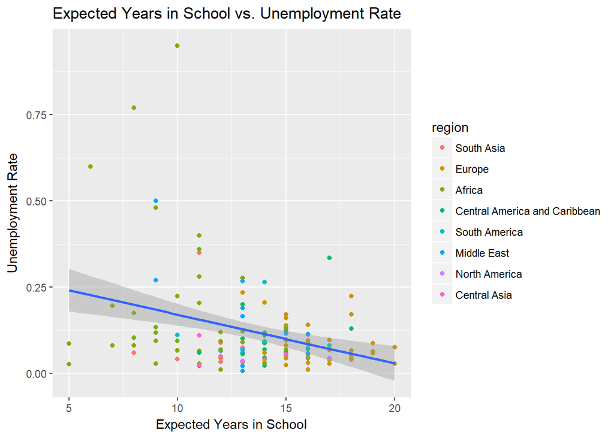

```r
df[(!is.na(df$school_years) & !is.na(df$unemployment) & !is.na(df$region)),] %>% # ignore missing values
  ggplot(aes(x = school_years, y = unemployment)) +
  labs(x = "Expected Years in School", y = "Unemployment Rate",
       title = "Expected Years in School vs. Unemployment Rate") +
  geom_point(mapping = aes(color = region)) + geom_smooth(method = lm)
```

Based on this plot, it appears that there is a general trend for unemployment rate in a country to decrease as the expected years in school increases. Additionally, we can see from the color mapping that Africa makes up most of the countries with lower expected years spent in school as well as higher unemployment rates. We can also observe that European countries tend to have the highest expected number of years in school.  
Next, we will plot education expenditures and unemployment rate. We will also mark the United States with a large dot to see how it compares with other countries.

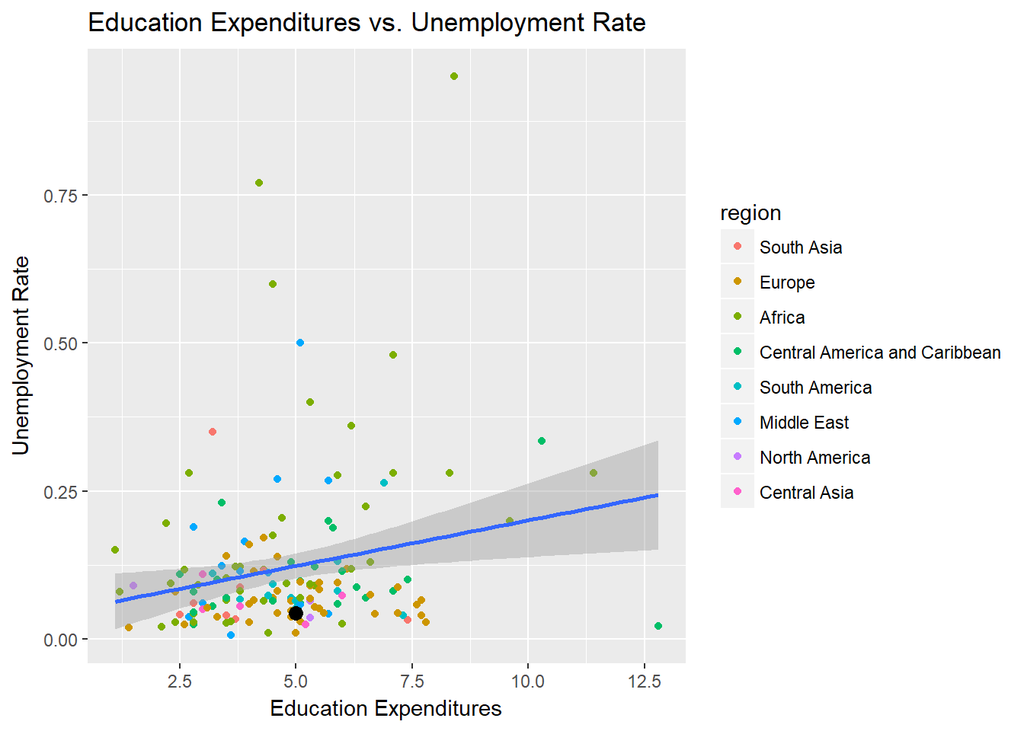

```r
df[(!is.na(df$education_exp) & !is.na(df$unemployment) & !is.na(df$region)),] %>% # ignore missing values
  ggplot(aes(x = education_exp, y = unemployment)) +
  labs(x = "Education Expenditures", y = "Unemployment Rate",
       title = "Education Expenditures vs. Unemployment Rate") +
  geom_point(mapping = aes(color = region)) + geom_point(data=df[df$country == "United States",],size=3) + geom_smooth(method = lm)
```

The results here are surprising. It appears that there is a positive linear trend in unemployment rate as education expenditures increase. This could be an indication that larger expenditures aren’t being used well, although it would require further information and analysis to make a conclusion. Additionally, the US hovers right around the average (4.77%) in education expenditures, but it has a lower unemployment rate than would be expected by the linear fit.  
Finally, we do the same for literacy.

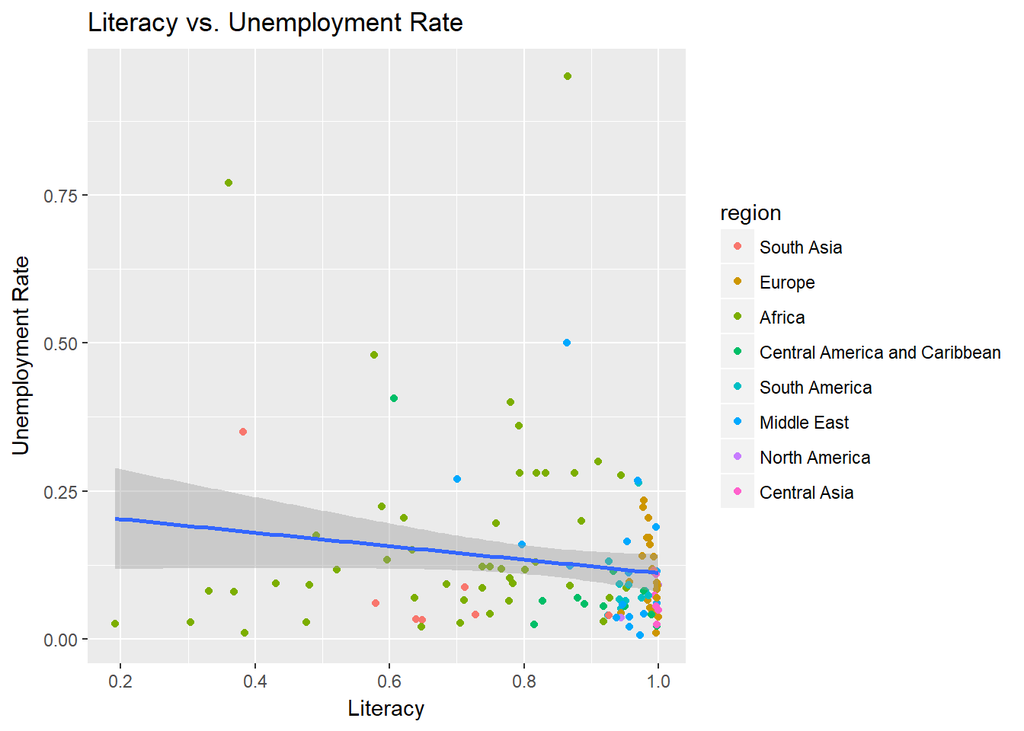

```r
df[(!is.na(df$literacy) & !is.na(df$unemployment) & !is.na(df$region)),] %>% # ignore missing values
  ggplot(aes(x = literacy, y = unemployment)) +
  labs(x = "Literacy", y = "Unemployment Rate",
       title = "Literacy vs. Unemployment Rate") +
  geom_point(mapping = aes(color = region)) +
  geom_smooth(method = lm)
```

This plot indicates that there could possibly be a slight decrease in unemployment as literacy increases. However, for the most part there seems to be no relationship between the two.

### **Building a Simple Linear Regression Model**

We will use the lm() function to build a [linear regression model](http://www.stat.yale.edu/Courses/1997-98/101/linreg.htm) to analyze relationship between expected years in school and unemployment.

```r
linear_model1 <- lm(unemployment ~ school_years, data=df)
linear_model1 %>% broom::tidy()
```

```
##           term    estimate   std.error statistic      p.value
## 1  (Intercept)  0.30269888 0.043375753  6.978527 7.367450e-11
## 2 school_years -0.01394175 0.003136143 -4.445510 1.626359e-05
```

Based on the results of our linear model, a country whose students are expected to spent 0 years in school will have an estimated unemployment rate of 30%. If the expected years in school goes up by a year, then the unemployment rate will decrease by around 1.4% on average. We can also decide whether there is a significant relationship between expected school years and unemployment based on a statistical significance test where the null hypothesis is no relationship. Since the p-value is less than 0.05, we can reject the null hypothesis. This suggests that there is a negative linear relationship between expected years spent in school and unemployment rate in a country.  
Now we build a linear regression model to analyze relationship between education expenditures and unemployment.

```r
linear_model2 <- lm(unemployment ~ education_exp, data=df)
linear_model2 %>% broom::tidy()
```

```
##            term   estimate   std.error statistic   p.value
## 1   (Intercept) 0.03924758 0.025339092  1.548894 0.1233001
## 2 education_exp 0.01506954 0.004916562  3.065056 0.0025385
```

We can model this linear relationship as a linear equation: `unemployment = .039 + .015 * education_exp`. Since the p-value is 0.0025 which is less than 0.05, we can says that there is a significant relationship between educational expenditures and unemployment.  
Lastly, let’s build a linear regression model for literacy and unemployment.

```r
linear_model3 <- lm(unemployment ~ literacy, data=df)
linear_model3 %>% broom::tidy()
```

```
##          term   estimate  std.error statistic      p.value
## 1 (Intercept)  0.2129305 0.05191128  4.101815 6.828604e-05
## 2    literacy -0.1087269 0.05993496 -1.814082 7.174688e-02
```

In this case, our p-value is 0.07 which is greater than 0.05. This means that we cannot reject the null hypothesis. As we predicted from our initial data visualization, there is no significant relationship between literacy and unemployment.

### **Multiple Linear Regression**

We can also combine our three variables to build a linear regression model using multiple predictors.

```r
linear_model4 <- lm(unemployment ~ education_exp + school_years + literacy, data=df)
linear_model4 %>% broom::tidy()
```

```
##            term    estimate   std.error  statistic      p.value
## 1   (Intercept)  0.22600584 0.064814728  3.4869519 0.0007099390
## 2 education_exp  0.02530772 0.006690124  3.7828477 0.0002558624
## 3  school_years -0.02147346 0.007079611 -3.0331407 0.0030373843
## 4      literacy  0.05747574 0.098192330  0.5853383 0.5595526886
```

In this case, we would reject the null hypothesis of no relationship for both education expenditures and expected year in school, but not for literacy. We can model this linear relationship as: `unemployment = 0.226 + 0.025 * education_exp - 0.021 * school_years + 0.057 * literacy`.

### **Unsupervised Machine Learning**

Unsupervised machine learning allows us to gain understanding of the structure of our dataset by finding hidden patterns in our data. We will be using an unsupervised method known as “[k-means clustering](http://stanford.edu/~cpiech/cs221/handouts/kmeans.html)” to see if we can find groups of countries that are similar to each other.  
In order to use clustering, we need to define the similarity between two countries in our dataset. The k-means clustering algorithm will use Euclidean distance as a measure to partition the dataset in k clusters of similar objects. For example, we could define similarity based on values for school life expectancy and education expenditure. We need to scale these values before passing them to the k[means algorithm because they are measured in different units. We choose k = 4 to partition into four clusters.

```r
set.seed(1234)
df <- na.omit(df) # need to omit all missing values
clusters <- kmeans(scale(df[, 2:3]), 4, nstart = 20)
clusters$centers
```

```
##   school_years education_exp
## 1  -0.08206340     0.7383337
## 2  -1.20686428    -0.7577640
## 3  -0.02635897     3.5186443
## 4   0.82530212    -0.2991646
```

These values are the centers for each of the four clusters. A country is in a cluster if its Euclidean distance to the cluster’s center is less than its distance to any other cluster.

### **Visualizing K-means clustering**

We can add the clusters as a column in the data frame and use ggplot to visualize the clusters.

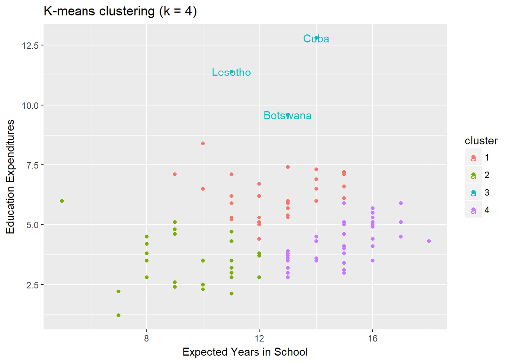

```r
df$cluster <- as.factor(clusters$cluster)
df %>%
  ggplot(aes(x=school_years, y=education_exp, color = cluster)) +
  geom_point() + geom_text(data=df[df$cluster == 3,], aes(label=country)) +
  labs(x = "Expected Years in School", y = "Education Expenditures",
         title = "K-means clustering (k = 4)")
```

We can visualize the four clusters than k-means partitions the dataset into. Clustering can also be used as a way of detecting outliers. We can see that Cluster 3 contains much fewer values than the other three clusters, meaning that these 3 values are far away from the remainder of the dataset. These three countries could potentially be considered outliers due to their high education expenditures.  
Now let’s try k-means with 6 clusters. We will now define similarity based on four data points: expected years in school, education expenditures, literacy, and unemployment rates.

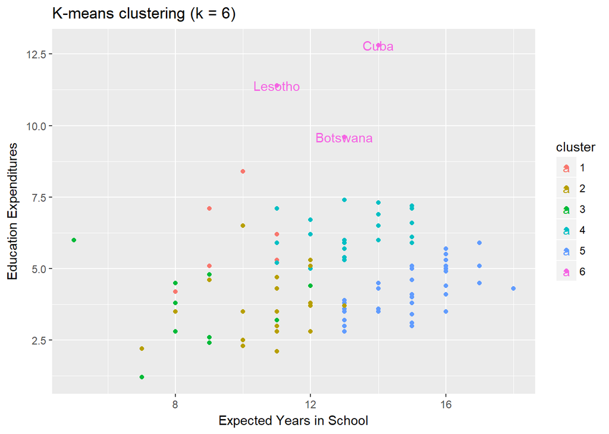

```r
set.seed(1234)
clusters <- kmeans(scale(df[, 2:5]), 6, nstart = 20)
df$cluster <- as.factor(clusters$cluster)

df %>%
  ggplot(aes(x=school_years, y=education_exp, color = cluster)) +
  geom_point() + geom_text(data=df[df$cluster == 6,], aes(label=country)) +
  labs(x = "Expected Years in School", y = "Education Expenditures",
         title = "K-means clustering (k = 6)")
```

Even using our additional data in computing similarity, Cuba, Lesotho, and Botswana still appear to be outliers. We can also see if countries from the same region tend to be in the same cluster.

```r
plyr::count(df[df$cluster == 2,], 'region')
```

```
##                          region freq
## 1                    South Asia    3
## 2                        Africa   14
## 3 Central America and Caribbean    1
## 4                   Middle East    1
## 5                  Central Asia    1
```

```r
plyr::count(df[df$cluster == 4,], 'region')
```

```
##                          region freq
## 1                    South Asia    1
## 2                        Europe    4
## 3                        Africa    5
## 4 Central America and Caribbean    4
## 5                 South America    4
## 6                   Middle East    2
## 7                 North America    1
## 8                  Central Asia    2
```

```r
plyr::count(df[df$cluster == 5,], 'region')
```

```
##                          region freq
## 1                    South Asia    1
## 2                        Europe   14
## 3                        Africa    3
## 4 Central America and Caribbean    2
## 5                 South America    6
## 6                   Middle East    9
## 7                  Central Asia    2
```

### **Summary**

Now that you have completed the tutorial, you should be able to scrape data from the CIA World Factbook and apply exploratory analysis, linear regression, and k-means clustering to gain some insights and understanding about your dataset. The CIA World Factbook also contains data about many more aspects of people, society, government, and economy in the world’s nations. There are many ways to apply data science and the techniques presented in this tutorial to this dataset and gain insights about our world. If you follow this tutorial, please feel free to send questions/suggestions to: kaman@phamdo.com.